# Code

Beginners and expert citizen scientists prefer similar species on iNaturalist, but experts contribute in average almost hundred times more data

Authors

Rodrigo Montiel

Manuele Bazzichetto

Florencia Grattarola

Published

February 3, 2025

We aim to identify users’ recording preferences according to their level of experience on the iNaturalist platform in Uruguay in order to understand the possible biases associated with the data.

**Workflow**

1. Data download
2. Users’ ranking
3. Species traits
4. Statistical analyses

```r
library(knitr)
library(tmap)
tmap_mode('view')
library(sf)
sf::sf_use_s2(FALSE)
library(httr)
library(jsonlite)
library(lubridate)
library(tidyverse)
```

## Data download

```r
observations <- read_csv('data/NatUY_observations_03-05.csv',
                         guess_max = 140000)
```

## Users’ ranking

First we need to detect those users that are not from Uruguay and remove the data generated by them from our dataset. To do this we created a function using the [iNaturalist API](https://api.inaturalist.org/v1/docs/).  
The function `getObserversNumObservations()` takes a list of users’ ids (`user_login_list`) and a location (`place_id`), and retrieves: the `user_id`, `user_login`, and `user_name`, the number of observations and species of the user on iNat and on the location (in our case, Uruguay, `place_id=7259`), and and the date when the user created their account (`user_created_at`).

```r
getObserversNumObservations <- function(user_login_list,
                                        place_id=7259){

  observers_num_observations <- tibble(user_id = numeric(),
                                       observations_iNat = numeric(),
                                       observations_NatUY = numeric(),
                                       species_iNat = numeric(),
                                       species_NatUY = numeric(),
                                       user_login = character(),
                                       user_created_at = lubridate::ymd_hms(),
                                       user_name = character())
  num_results <- 1
  for (user_login in user_login_list) {
    if ((num_results %% 10) + 10 == 10) {
      Sys.sleep(10) # The API needs a delay because otherwise it gives an error.
      # Every 10 users, the code stops for 10 second
    }
    call <- str_glue('https://api.inaturalist.org/v1/observations/observers',
                     '?user_login={user_login}&',
                     'place_id={place_id}')

    get_json_call <- GET(url = call) %>%
      content(as = 'text') %>%
      fromJSON(flatten = TRUE)

    if(!'error' %in% names(get_json_call)) {
      results <- as_tibble(get_json_call$results)
      observer_num_observations <-
        tibble(user_id = results$user_id,
               observations_iNat = results$user.observations_count,
               observations_NatUY = results$observation_count,
               species_iNat = results$user.species_count,
               species_NatUY = results$species_count,
               user_login = results$user.login,
               user_created_at = results$user.created_at,
               user_name = results$user.name)
      observers_num_observations <- rbind(observers_num_observations,
                                          observer_num_observations)
      cat(num_results, 'user:', user_login, ',',
          observer_num_observations$observations_iNat, 'observations on iNat', '\n')
    }
    else {
      observer_num_observations <- tibble(user_id = NA,
                                          observations_iNat = NA,
                                          observations_NatUY = NA,
                                          species_iNat = NA,
                                          species_NatUY = NA,
                                          user_login = user_login,
                                          user_created_at = NA,
                                          user_name = NA)
      observers_num_observations <- rbind(observers_num_observations,
                                          observer_num_observations)
      cat('user:', user_login, '--> NOT FOUND', '\n')
    }
    num_results <- nrow(observers_num_observations) + 1
  }
  return(observers_num_observations)
}

users_dataset <- observations %>% distinct(user_login)

observers_num_observations <- getObserversNumObservations(users_dataset$user_login)

# write_csv(observers_num_observations,
#           'data/observers_num_observations.csv')
```

```r
uruguayans <- observers_num_observations %>%
  mutate(proportion_natuy_inat = round(observations_NatUY*100/observations_iNat, 3),
         uruguayan = ifelse(proportion_natuy_inat>40 , 'yes', 'no')) %>%
  filter(uruguayan == 'yes')

observations_uy <- filter(observations, user_login %in% uruguayans$user_login)
```

After discarding foreign users, we calculated the number of records uploaded (`observations`), the time active on the platform (taking the dates of the first and last records uploaded, `activity_time`) and the number of records over time (the total number of records uploaded divided by the active time, `observations_by_time`).

Finally, we **ranked** the users according to their level of experience in the platform by calculating an index, such that:

$Index = \text{category\_score} \cdot \left( w_1 \cdot \text{observations}_{\text{norm}} + w_2 \cdot \text{activity\_time}_{\text{norm}} + w_3 \cdot \text{observations\_by\_time}_{\text{norm}} \right)$

We used the `category_score` to account for the categories we had previously established, thus, the outcome is a ranking that has experts, intermediates, and beginners sorted within each category.

```r
normalise <- function(x) {
  (x - min(x)) / (max(x) - min(x))
}

users_dataset <- observations_uy %>%
    group_by(user_login) %>%
    summarise(
        first_record = min(created_at),
        last_record = max(created_at),
        observations = n(),
        activity_time = as.numeric(difftime(last_record, first_record, units = 'days')) + 1,
        observations_by_time = observations / activity_time
    ) %>%
    filter(observations >= 3 & activity_time > 3) %>%
    mutate(
        user_category = ifelse(
            observations >= 1000 & activity_time >= 365 & observations_by_time >= 0.6, 'expert',
            ifelse(observations >= 50 & activity_time > 90 & observations_by_time > 0.2, 'intermediate', 'beginner')
        ),
        category_score = case_when(
            user_category == 'expert' ~ 10,
            user_category == 'intermediate' ~ 1,
            user_category == 'beginner' ~ 0.01
        )
    ) %>%
    mutate(
        # Normalize variables
        observations_norm = normalise(observations),
        activity_time_norm = normalise(activity_time),
        observations_by_time_norm = normalise(observations_by_time)
    ) %>%
    mutate(
        # Define weights for variables
        w1 = 2/3,  # observations
        w2 = 1/6,  # activity_time
        w3 = 1/6,  # observations_by_time
        # Calculate the index with a category score multiplier
        index = category_score * (
            w1 * observations_norm +
            w2 * activity_time_norm +
            w3 * observations_by_time_norm
        )
    ) %>%
    # Rank users based on the index
    arrange(desc(index)) %>%
    mutate(ranking = row_number())

# write_csv(users_dataset, 'data/users_dataset.csv')
```

```r
# top 5 users per category
users_dataset %>%
  group_by(category_score) %>%
  slice_head(n = 5) %>% ungroup() %>%
  select(ranking, user_category,user_login,
         observations, activity_time, observations_by_time) %>%
  arrange(ranking) %>%
  rename(Ranking = ranking,
         Category = user_category,
         User = user_login,
         `N of observations` = observations,
         `Activity (in days)` = activity_time,
         `N of observations per day` = observations_by_time)  %>%
  kableExtra::kbl(format.args = list(decimal.mark = '.',
                                     big.mark = ","),
                  digits=2,
                  booktabs = T) %>%
  kableExtra::kable_styling(latex_options = c('striped', 'hold_position'))
```

Top 5 users per expertise category

| Ranking | Category | User | N of observations | Activity (in days) | N of observations per day |
| --- | --- | --- | --- | --- | --- |
| 1 | expert | santiagomailhos | 7,106 | 1,909.61 | 3.72 |
| 2 | expert | luisvescia | 5,030 | 858.86 | 5.86 |
| 3 | expert | ornitoloca | 3,554 | 1,342.43 | 2.65 |
| 4 | expert | enriquecenoz | 3,096 | 579.77 | 5.34 |
| 5 | expert | msilvera | 2,484 | 1,673.52 | 1.48 |
| 21 | intermediate | mirmeleon | 1,121 | 2,146.10 | 0.52 |
| 22 | intermediate | rafatosi | 1,143 | 1,995.26 | 0.57 |
| 23 | intermediate | gabriellaufer | 853 | 1,642.21 | 0.52 |
| 24 | intermediate | leo_lagos | 794 | 1,685.25 | 0.47 |
| 25 | intermediate | amailhos | 638 | 1,907.84 | 0.33 |
| 113 | beginner | lyn_loveless | 285 | 14.88 | 19.15 |
| 114 | beginner | intiporley | 4 | 3,165.88 | 0.00 |
| 115 | beginner | smantaras | 382 | 1,994.36 | 0.19 |
| 116 | beginner | gusper | 224 | 2,177.10 | 0.10 |
| 117 | beginner | mariusvk | 166 | 13.46 | 12.34 |

```r
# users per category
users_dataset %>%
  group_by(category_score, user_category) %>%
  count() %>% ungroup() %>%
  arrange(category_score) %>% select(-category_score) %>%
  mutate(`%` = scales::label_percent()(n / sum(n))) %>%
  rename(Category= user_category,
         `N of users`=n)  %>%
  kableExtra::kbl(format.args = list(decimal.mark = '.',
                                     big.mark = ","),
                  digits=2,
                  booktabs = T) %>%
  kableExtra::kable_styling(latex_options = c('striped', 'hold_position'))
```

Number and % of users per category

| Category | N of users | % |
| --- | --- | --- |
| beginner | 824 | 88.0% |
| intermediate | 92 | 9.8% |
| expert | 20 | 2.1% |

```r
# observations per category
left_join(observations_uy, users_dataset %>%
              select(user_login, observations,category_score, user_category, ranking)) %>%
    filter(!is.na(user_category)) %>%
    group_by(category_score, user_category) %>%
    count() %>% ungroup() %>%
    arrange(category_score) %>% select(-category_score) %>%
    mutate(`%` = scales::label_percent()(n / sum(n))) %>%
    rename(Category= user_category,
           `N of observations`=n)  %>%
    kableExtra::kbl(format.args = list(decimal.mark = '.',
                                     big.mark = ","),
                  digits=2,
                  booktabs = T) %>%
    kableExtra::kable_styling(latex_options = c('striped', 'hold_position'))
```

Number and % of observations per category

| Category | N of observations | % |
| --- | --- | --- |
| beginner | 21,498 | 22.2% |
| intermediate | 30,351 | 31.4% |
| expert | 44,808 | 46.4% |

## Species traits

First, we exported the list of species for tetrapods and plants.

```r
species_list <- observations_uy %>%
  filter(quality_grade == 'research') %>%
  select(taxon_kingdom_name, taxon_phylum_name,
         taxon_class_name, taxon_order_name, taxon_family_name,
         taxon_genus_name, taxon_species_name) %>%
  filter(str_count(taxon_species_name, '\\S+') == 2)

# (str_count(scientific_name, '\\S+') ==2) allows us to select
# those records that have two words in the scientific_name field

## tetrapods
tetra <- species_list %>%
  filter(taxon_class_name == 'Aves' |
           taxon_class_name == 'Amphibia' |
           taxon_class_name == 'Mammalia' |
           taxon_class_name == 'Reptilia') %>%
  group_by(taxon_class_name, taxon_species_name) %>%
  count()

# write_csv(tetra,'data/tetra_list.csv')

## plants
dico <- species_list %>%
  filter(taxon_family_name == 'Fabaceae' |
           taxon_family_name == 'Cactaceae' |
           taxon_family_name == 'Asteraceae'|
           taxon_family_name == 'Solanaceae') %>%
  group_by(taxon_family_name, taxon_species_name) %>%
  count()

# write_csv(dico,'data/dico_list.csv')
```

Then, using the list of species, we conducted a literature search, at the national level, to identify the following traits for each species: *geographic distribution*, *conservation status* and *size* or *growth form* depending on whether it was an animal or a plant.

```r
tetra_traits <- read_csv('data/tetra_traits.csv')
dico_traits <- read_csv('data/dico_traits.csv')
```

We identified 33 tetrapod species and 52 plant species listed as non-native or domestic/cultivated (e.g. dog, horse, tobacco) in Uruguay, and discarded them from the analyses.

```r
dico_traits %>%
  filter(grepl('non', remarks)) %>%
  distinct(taxon_family_name, taxon_species_name) %>%
  arrange(taxon_family_name, taxon_species_name) %>%
  kableExtra::kbl(booktabs = T) %>%
  kableExtra::kable_styling(latex_options = c('striped', 'hold_position')) %>%
  kableExtra::scroll_box(height = '300px')
```

| taxon_family_name | taxon_species_name |
| --- | --- |
| Asteraceae | Bidens aurea |
| Asteraceae | Calendula officinalis |
| Asteraceae | Carduus nutans |
| Asteraceae | Carduus tenuiflorus |
| Asteraceae | Cladanthus mixtus |
| Asteraceae | Cosmos bipinnatus |
| Asteraceae | Cosmos sulphureus |
| Asteraceae | Cotula nigellifolia |
| Asteraceae | Dimorphotheca ecklonis |
| Asteraceae | Dittrichia viscosa |
| Asteraceae | Euryops chrysanthemoides |
| Asteraceae | Gazania rigens |
| Asteraceae | Helenium amarum |
| Asteraceae | Helianthus annuus |
| Asteraceae | Hypochaeris glabra |
| Asteraceae | Lactuca sativa |
| Asteraceae | Pseudogynoxys chenopodioides |
| Asteraceae | Senecio angulatus |
| Asteraceae | Senecio tamoides |
| Asteraceae | Tanacetum parthenium |
| Asteraceae | Taraxacum erythrospermum |
| Asteraceae | Tragopogon porrifolius |
| Asteraceae | Youngia japonica |
| Asteraceae | Zinnia elegans |
| Cactaceae | Austrocylindropuntia subulata |
| Cactaceae | Opuntia cochenillifera |
| Cactaceae | Opuntia ficus-indica |
| Cactaceae | Parodia fusca |
| Cactaceae | Selenicereus undatus |
| Fabaceae | Acacia elata |
| Fabaceae | Acacia mearnsii |
| Fabaceae | Acacia podalyriifolia |
| Fabaceae | Acacia retinodes |
| Fabaceae | Albizia julibrissin |
| Fabaceae | Bauhinia variegata |
| Fabaceae | Glycine max |
| Fabaceae | Lathyrus latifolius |
| Fabaceae | Lathyrus odoratus |
| Fabaceae | Senna didymobotrya |
| Fabaceae | Trifolium angustifolium |
| Fabaceae | Trifolium fragiferum |
| Fabaceae | Trifolium subterraneum |
| Fabaceae | Vachellia karroo |
| Fabaceae | Vicia villosa |
| Fabaceae | Wisteria sinensis |
| Solanaceae | Brugmansia arborea |
| Solanaceae | Nicandra physalodes |
| Solanaceae | Nicotiana tabacum |
| Solanaceae | Physalis peruviana |
| Solanaceae | Solanum lycopersicum |
| Solanaceae | Solanum tuberosum |
| Solanaceae | Streptosolen jamesonii |

```r
tetra_traits %>%
  filter(grepl('Casual', remarks)) %>%
  distinct(taxon_class_name, taxon_species_name) %>%
  arrange(taxon_class_name, taxon_species_name) %>%
  kableExtra::kbl(booktabs = T) %>%
  kableExtra::kable_styling(latex_options = c('striped', 'hold_position')) %>%
  kableExtra::scroll_box(height = '300px')
```

| taxon_class_name | taxon_species_name |
| --- | --- |
| Amphibia | Lithobates catesbeianus |
| Aves | Agapornis personatus |
| Aves | Amazona aestiva |
| Aves | Anas platyrhynchos |
| Aves | Anser anser |
| Aves | Aratinga nenday |
| Aves | Carduelis carduelis |
| Aves | Catharus ustulatus |
| Aves | Chloris chloris |
| Aves | Columba livia |
| Aves | Corvus splendens |
| Aves | Fulmarus glacialis |
| Aves | Gallus gallus |
| Aves | Meleagris gallopavo |
| Aves | Melopsittacus undulatus |
| Aves | Motacilla alba |
| Aves | Numida meleagris |
| Aves | Nymphicus hollandicus |
| Aves | Passer domesticus |
| Aves | Pavo cristatus |
| Aves | Sturnus vulgaris |
| Mammalia | Axis axis |
| Mammalia | Canis familiaris |
| Mammalia | Dama dama |
| Mammalia | Felis catus |
| Mammalia | Lepus europaeus |
| Mammalia | Mus musculus |
| Mammalia | Oryctolagus cuniculus |
| Mammalia | Rattus norvegicus |
| Mammalia | Rattus rattus |
| Mammalia | Sus scrofa |
| Reptilia | Hemidactylus mabouia |
| Reptilia | Tarentola mauritanica |

## Final datasets

Finally we combine the observations, with the users’ categorisation and the species traits, and create two tables (for tetrapods and plants), with observations as rows.

```r
observations_uy <- left_join(observations_uy,
                             users_dataset %>%
                               select(user_login,
                                      observations,
                                      user_category,
                                      ranking)) %>%
  filter(!is.na(user_category))

# write_csv(observations_uy, 'data/observations_uy.csv')
```

And then, we classify the quantitative traits using qualitative values.

- **Tetrapods**

```r
# tetrapods
tetra_data <- left_join(observations_uy,
                        tetra_traits %>%
                          filter(!grepl('Casual', remarks))) %>%
  filter(!is.na(Distribution))

tetra_data <- tetra_data %>%
  mutate(distribution = case_when(Distribution <= 5 ~ 'narrow',
                                  Distribution > 5 & Distribution <= 16 ~ 'medium',
                                  Distribution > 16 ~ 'wide',
                                  is.na(Distribution) ~ 'not assessed')) %>%
  mutate(size = case_when(taxon_class_name == 'Mammalia' &
                            Size < 50 ~ 'small',
                          taxon_class_name == 'Mammalia' &
                            Size >= 50 & Size < 200 ~ 'medium',
                          taxon_class_name == 'Mammalia' &
                            Size >= 200 ~ 'large',
                          taxon_class_name == 'Amphibia' &
                            Size < 5 ~ 'small',
                          taxon_class_name == 'Amphibia' &
                            Size >= 5 & Size < 10 ~ 'medium',
                          taxon_class_name == 'Amphibia' &
                            Size >= 10 ~ 'large',
                          taxon_class_name == 'Reptilia' &
                            Size < 50 ~ 'small',
                          taxon_class_name == 'Reptilia' &
                            Size >= 50 & Size < 100 ~ 'medium',
                          taxon_class_name == 'Reptilia' &
                            Size >= 100 ~ 'large',
                          taxon_class_name == 'Aves' &
                            Size < 20 ~ 'small',
                          taxon_class_name == 'Aves' &
                            Size >= 20 & Size < 50 ~ 'medium',
                          taxon_class_name == 'Aves' &
                            Size >= 50 ~ 'large'))

# write_csv(tetra_data, "data/tetra_data.csv")
```

- **Plants**

```r
plants_data <- left_join(observations_uy,
                        dico_traits %>%
                         filter(!grepl('native', remarks))) %>%
  filter(!is.na(Distribution))

plants_data <- plants_data %>%
  mutate(distribution = case_when(Distribution <= 5 ~ 'narrow',
                                  Distribution > 5 & Distribution <= 16 ~ 'medium',
                                  Distribution > 16 ~ 'wide',
                                  is.na(Distribution) ~ 'not assessed')) %>%
  rename(growth_form = Habito1)


# write_csv(dico_data, "data/dico_data.csv")
```

## Statistical analyses

First we transform the data, ordering the qualitative variables and scaling the quantitative variables.

```r
tetrapods <- tetra_data %>%
  group_by(user_login) %>%
  mutate(n_observations = n()) %>% ungroup() %>%
  filter(n_observations>=3) %>%
  mutate(status = factor(IUCNglobal,
                         levels = c('CR','EN','VU',
                                    'NT', 'DD', 'NE',
                                    'LC'))) %>%
  select(ranking, dist=Distribution, size=Size,
         status, taxon=taxon_class_name,
         state=place_state_name,
         user_category, user_login, taxon_species_name) %>%
  mutate(size_scaled = scale(size, center = TRUE)[,1],
         dist_scaled = scale(dist, center = TRUE)[,1],
         log_dist = log(dist))

plants <- plants_data %>%
  group_by(user_login) %>%
  mutate(n_observations = n()) %>% ungroup() %>%
  filter(n_observations>=3) %>%
  mutate(status = factor(IUCNglobal,
                         levels = c('CR','EN','VU',
                                    'NT', 'DD', 'NE',
                                    'LC')),
         growth = factor(growth_form,
                         levels = c('herb', 'vine',
                                    'liana', 'subshrub',
                                    'shrub', 'tree'))) %>%
  select(ranking, dist=Distribution, growth,
         status, taxon=taxon_family_name,
         state=place_state_name,
         user_category, user_login, taxon_species_name) %>%
  mutate(dist_scaled = scale(dist, center = TRUE)[,1],
         log_dist = log(dist))
```

Summary of the data

```r
# bind_rows(tetrapods,plants) %>% nrow() # number of records
# bind_rows(tetrapods,plants) %>% distinct(taxon_species_name) %>% count  # number of species
# bind_rows(tetrapods,plants) %>% group_by(user_category) %>% count()
# bind_rows(tetrapods,plants) %>% distinct(user_login, .keep_all = T) %>% group_by(user_category) %>% count()

tibble(Group = c('tetrapods', 'plants'),
       Users = c(nrow(tetrapods %>%
                          distinct(user_login)),
                   nrow(plants %>%
                        distinct(user_login))),
       Observations = c(nrow(tetrapods), nrow(plants)),
       Species = c(nrow(tetrapods %>%
                          distinct(taxon_species_name)),
                   nrow(plants %>%
                        distinct(taxon_species_name)))) %>%
  janitor::adorn_totals() %>%
  kableExtra::kbl(format.args = list(decimal.mark = '.',
                                     big.mark = ","),
                  digits=2,
                  booktabs = T) %>%
  kableExtra::kable_styling(latex_options = c('striped', 'hold_position'))
```

| Group | Users | Observations | Species |
| --- | --- | --- | --- |
| tetrapods | 358 | 22,918 | 602 |
| plants | 291 | 10,821 | 530 |
| Total | 649 | 33,739 | 1,132 |

- Plots

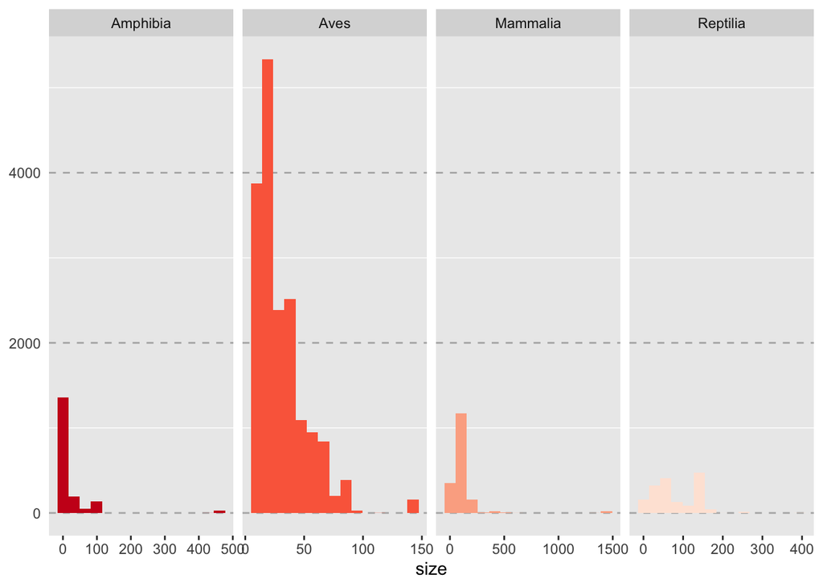

```r
##### TETRAPODS

# size plot
ggplot(data = tetrapods, aes(x = size, fill=taxon)) +
  geom_histogram(position = 'identity',
                 bins = 15, show.legend = F) +
  facet_grid(~taxon, scales = 'free') +
  scale_fill_brewer(palette = 'Reds', direction = -1) +
  ggpubr::theme_cleveland() +
  labs(x= 'size', y='number of records')
```

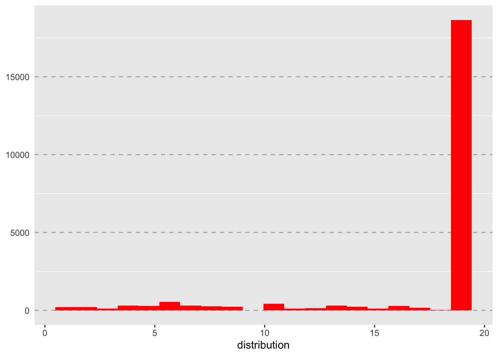

```r
# distribution plot
ggplot(data = tetrapods, aes(x = dist)) +
  geom_histogram(bins=20, fill='red') +
  ggpubr::theme_cleveland() +
  labs(x= 'distribution', y='number of records')
```

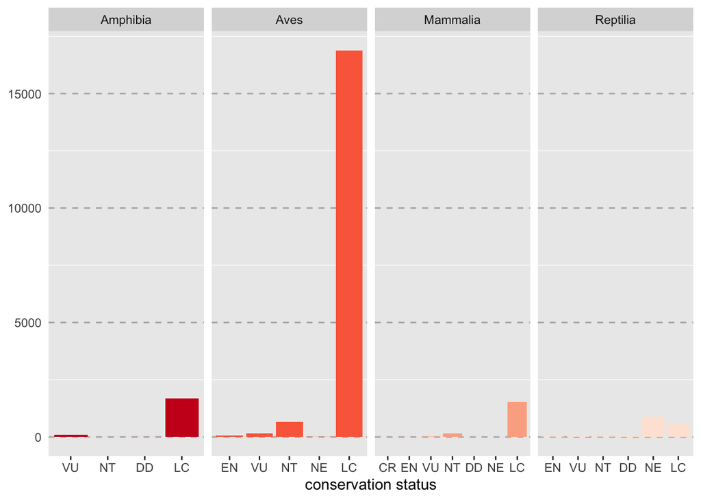

```r
# conservation status plot
ggplot(data = tetrapods, aes(x = status, fill=taxon)) +
  geom_histogram(stat = 'count', show.legend = F) +
  facet_grid(~taxon, scales = 'free') +
  scale_fill_brewer(palette = 'Reds', direction = -1) +
  ggpubr::theme_cleveland() +
  labs(x= 'conservation status', y='number of records')
```

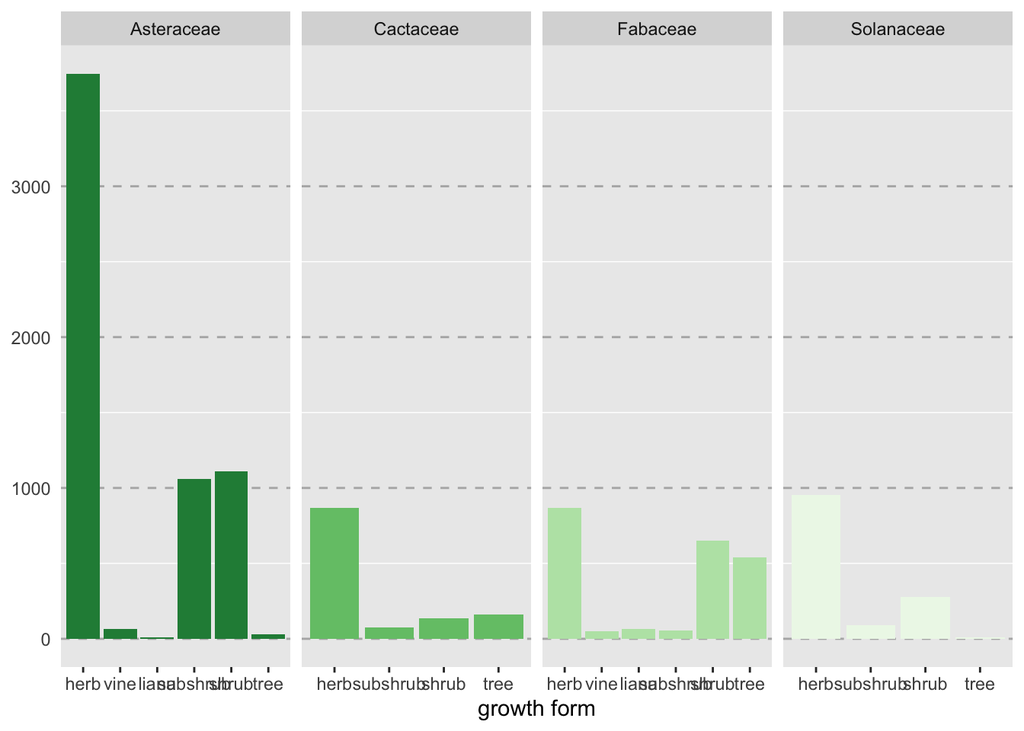

```r
##### PLANTS
# growth plot
ggplot(data = plants, aes(x = growth, fill=taxon)) +
  geom_histogram(stat = 'count', show.legend = F) +
  facet_grid(~taxon, scales = 'free') +
  scale_fill_brewer(palette = 'Greens', direction = -1) +
  ggpubr::theme_cleveland() +
  labs(x= 'growth form', y='number of records')
```

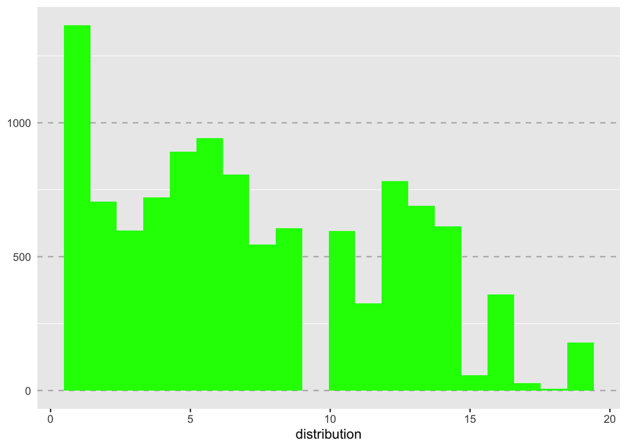

```r
# distribution plot
ggplot(data = plants, aes(x = dist)) +
  geom_histogram(bins=20, fill='green') +
  ggpubr::theme_cleveland() +
  labs(x= 'distribution', y='number of records')
```

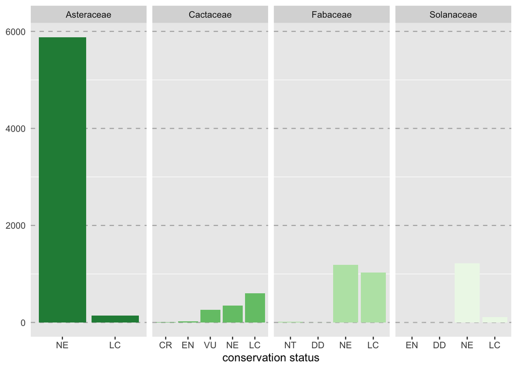

```r
# conservation status plot
ggplot(data = plants, aes(x = status, fill=taxon)) +
  geom_histogram(stat = 'count', show.legend = F) +
  facet_grid(~taxon, scales = 'free') +
  scale_fill_brewer(palette = 'Greens', direction = -1) +
  ggpubr::theme_cleveland() +
  labs(x= 'conservation status', y='number of records')
```